# Dataverkenning soortenmeetnetten

Toon Westra

Toon.Westra@inbo.be

# Inleiding

Op deze website worden de ingevoerde telgegevens in [meetnetten.be](https://www.meetnetten.be/) verkent. [meetnetten.be](https://www.meetnetten.be/) is een citizen science project dat als doel heeft om Vlaamse en Europese prioritaire soorten te monitoren ter ondersteuning van het Vlaamse natuurbeleid. [meetnetten.be](https://www.meetnetten.be/) bestaat uit een reeks gestructureerde meetnetten die werden ontwikkeld door het Instituut voor Natuur- en Bosonderzoek. Natuurpunt Studie staat in voor de coördinatie van het veldwerk en de telgegevens worden ingezameld door vrijwilligers.

[figure not shown]

# Data

We maken gebruik van een export uit de meetnetten-databank met ingevoerde gegevens t.e.m. versie2020-01-10.

# Resultaten van de dataverkenning

## Overzichtstabellen

Op basis van deze gegevens geven we per soortengroep een overzicht van:

- monitoringsinspanning uitgedrukt in aantal tellingen en aantal tellers
- totaal, gemiddeld en maximum getelde aantallen voor de primaire soorten
- totaal getelde aantallen voor de overige soorten

## Figuren

Een eerste figuur geeft de evolutie van de getelde aantallen binnen het seizoen weer en dit voor elk jaar waarin er geteld werd. Onderstaand voorbeeld toont het getelde aantal Boomkikker adulten. De stippelijnen verbinden tellingen van eenzelfde locatie. Op basis hiervan krijg je een idee hoe de getelde aantallen binnen een telseizoen variëren.

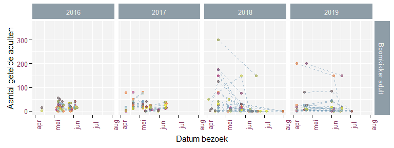

Indien er veel tellocaties zijn, is het moeilijk om nog een patroon te herkennen in bovenstaande figuur. Daarom tonen we ook onderstaande figuur waarin de blauwe lijn de gemiddelde evolutie toont binnen het telseizoen en de grijze banden aan beide kanten van de blauwe lijn de onzekerheid aangeven op deze gemiddelde evolutie. Een dergelijke figuur vraagt een minimum aantal telgegevens en daarom is het niet mogelijk om deze figuur voor alle soorten te maken.

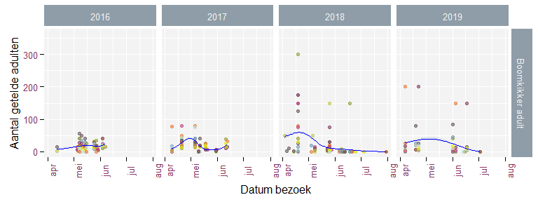

Ten slotte tonen we ook een figuur met het gemiddeld aantal getelde individuen per jaar (rode bollen) en het 95%-betrouwbaarheidsinterval hierop (rode verticale strepen). Op basis hiervan kunnen de gemiddelde aantallen tussen verschillende jaren vergeleken worden. Indien de betrouwbaarheidsintervallen van verschillende jaren niet overlappen, kunnen we vrij zeker zijn dat er werkelijk een verschil is in populatiegrootte.

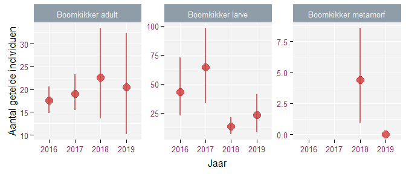

# Amfibieën

## Overzicht monitoringsinspanning

| meetnet | monitoringsinspanning | 2016 | 2017 | 2018 | 2019 |
| --- | --- | --- | --- | --- | --- |
| Boomkikker | aantal tellingen | 106 | 107 | 99 | 62 |
|  | aantal tellers | 8 | 7 | 9 | 6 |
| Kamsalamander | aantal tellingen |  | 105 | 124 | 195 |
|  | aantal tellers |  | 15 | 17 | 15 |
| Knoflookpad | aantal tellingen |  | 12 | 15 | 22 |
|  | aantal tellers |  | 2 | 7 | 4 |
| Rugstreeppad | aantal tellingen |  |  | 38 | 45 |
|  | aantal tellers |  |  | 4 | 12 |
| Vuursalamander | aantal tellingen | 86 | 107 | 96 | 60 |
|  | aantal tellers | 45 | 49 | 48 | 38 |

## Overzicht getelde aantallen

### Primaire soorten

[output not shown]

### Overige soorten

| soort_nl | soort_wet | levensstadium | 2016 | 2017 | 2018 | 2019 |
| --- | --- | --- | --- | --- | --- | --- |
| Alpenwatersalamander | Ichthyosaura alpestris | adult | 0 | 668 | 1220 | 1060 |
|  |  | juveniel | 0 | 0 | 5 | 6 |
|  |  | larve | 68 | 103 | 298 | 571 |
| Boomkikker | Hyla arborea | adult | 0 | 0 | 7 | 39 |
|  |  | larve | 0 | 0 | 19 | 3209 |
|  |  | metamorf | 0 | 0 | 0 | 20 |
| Bruine kikker | Rana temporaria | adult | 0 | 4 | 5 | 14 |
|  |  | juveniel | 0 | 0 | 2 | 18 |
|  |  | larve | 25 | 600 | 0 | 85 |
|  |  | metamorf | 0 | 0 | 110 | 15 |
| Gewone pad | Bufo bufo | adult | 0 | 9 | 2 | 36 |
|  |  | juveniel | 0 | 0 | 0 | 11 |
|  |  | juveniel (>2cm) | 0 | 0 | 0 | 2 |
|  |  | larve | 0 | 2500 | 64 | 5793 |
| Heikikker | Rana arvalis | adult | 0 | 250 | 21 | 47 |
|  |  | larve | 0 | 0 | 6 | 0 |
| Kamsalamander | Triturus cristatus | adult | 0 | 0 | 5 | 0 |
|  |  | larve | 103 | 0 | 44 | 65 |
| Kleine water/Vinpootsalamander | Lissotriton spec. | adult | 0 | 0 | 0 | 1 |
|  |  | larve | 0 | 0 | 103 | 183 |
| Kleine watersalamander | Lissotriton vulgaris | adult | 0 | 305 | 933 | 385 |
|  |  | juveniel | 0 | 0 | 18 | 0 |
|  |  | larve | 362 | 103 | 368 | 720 |
| Knoflookpad | Pelobates fuscus |  | 0 | 0 | 0 | 2 |
| Meerkikker | Pelophylax ridibundus | adult | 0 | 0 | 2 | 0 |
|  |  | larve | 0 | 6 | 0 | 0 |
| Poelkikker | Pelophylax lessonae | adult | 0 | 0 | 50 | 14 |
| Rugstreeppad | Bufo calamita |  | 0 | 0 | 3 | 0 |
| Vinpootsalamander | Lissotriton helveticus |  | 0 | 36 | 161 | 112 |
|  |  | larve | 30 | 0 | 31 | 0 |
| groene-kikker-complex | Pelophylax esculenta synklepton | adult | 0 | 0 | 8 | 21 |
|  |  | juveniel | 0 | 0 | 0 | 1 |
|  |  | larve | 0 | 0 | 1039 | 44 |

## Verkenning getelde aantallen

### Boomkikker

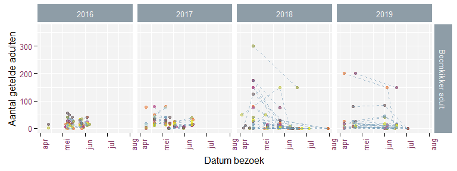

Figuur 1: Evolutie getelde aantallen binnen telperiode: Boomkikker - adult

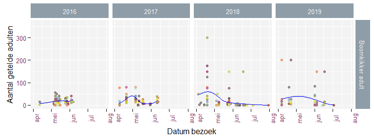

Figuur 2: Evolutie getelde aantallen binnen telperiode: Boomkikker - adult

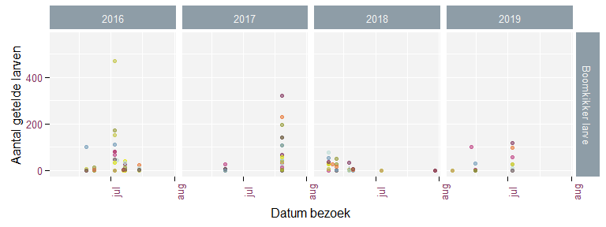

Figuur 3: Evolutie getelde aantallen binnen telperiode: Boomkikker - larve

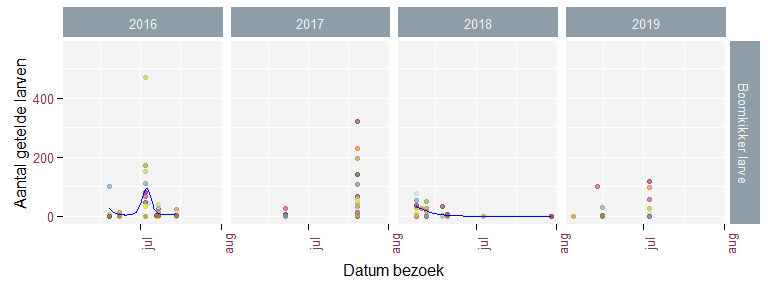

Figuur 4: Evolutie getelde aantallen binnen telperiode: Boomkikker - larve

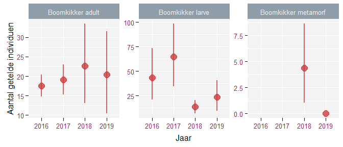

Figuur 5: Evolutie gemiddelde getelde aantallen per bezoek: Boomkikker

### Knoflookpad

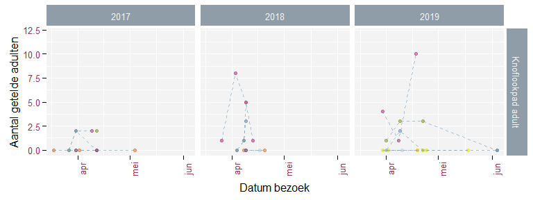

Figuur 6: Evolutie getelde aantallen binnen telperiode: Knoflookpad - adult

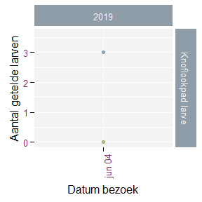

Figuur 7: Evolutie getelde aantallen binnen telperiode: Knoflookpad - larve

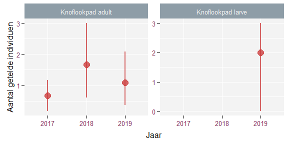

Figuur 8: Evolutie gemiddelde getelde aantallen per bezoek: Knoflookpad

### Rugstreeppad

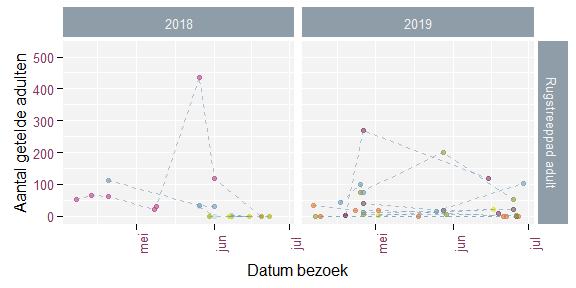

Figuur 9: Evolutie getelde aantallen binnen telperiode: Rugstreeppad - adult

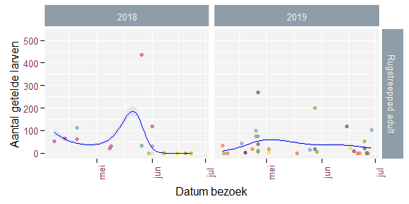

Figuur 10: Evolutie getelde aantallen binnen telperiode: Rugstreeppad - adult

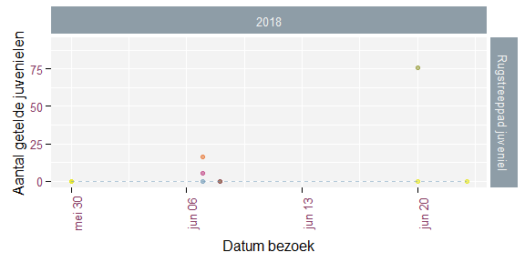

Figuur 11: Evolutie getelde aantallen binnen telperiode: Rugstreeppad - juveniel

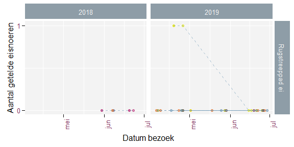

Figuur 12: Evolutie getelde aantallen binnen telperiode: Rugstreeppad - ei

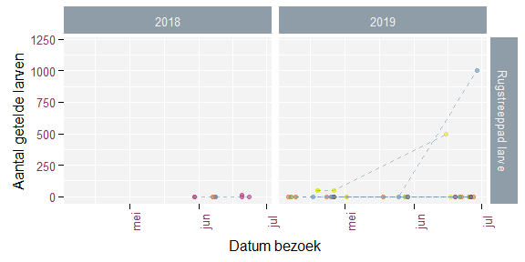

Figuur 13: Evolutie getelde aantallen binnen telperiode: Rugstreeppad - larve

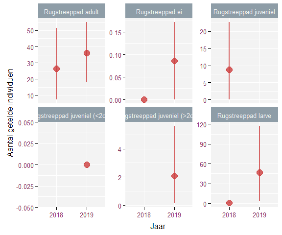

Figuur 14: Evolutie gemiddelde getelde aantallen per bezoek: Rugstreeppad

### Kamsalamander

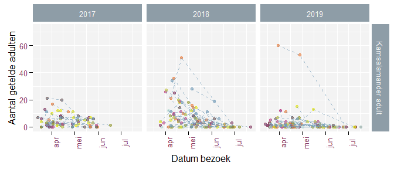

Figuur 15: Evolutie getelde aantallen binnen telperiode: Kamsalamander - adult

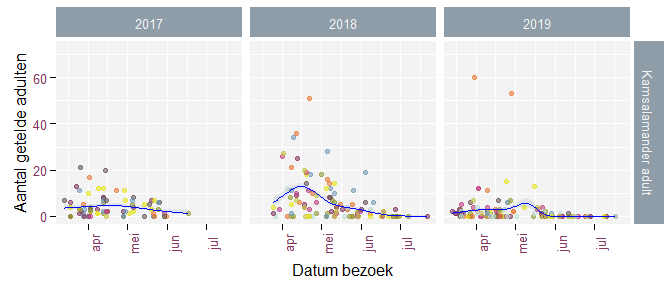

Figuur 16: Evolutie getelde aantallen binnen telperiode: Kamsalamander - adult

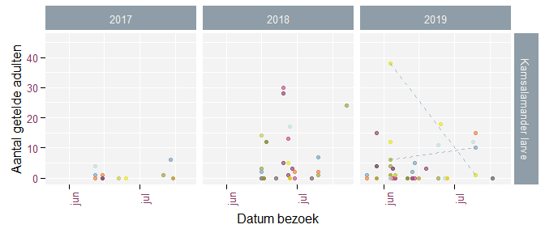

Figuur 17: Evolutie getelde aantallen binnen telperiode: Kamsalamander - larve

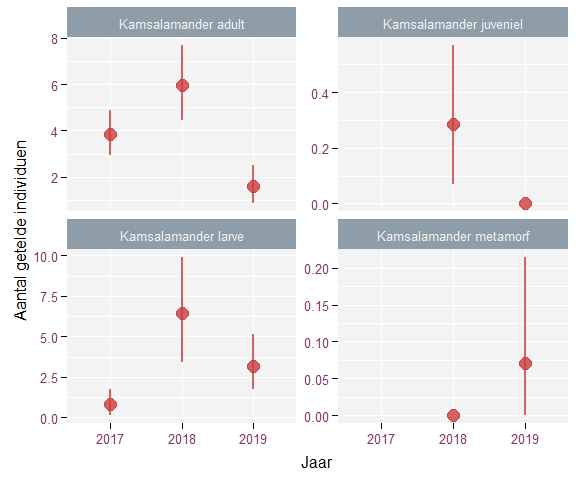

Figuur 18: Evolutie gemiddelde getelde aantallen per bezoek: Kamsalamander

### Vuursalamander

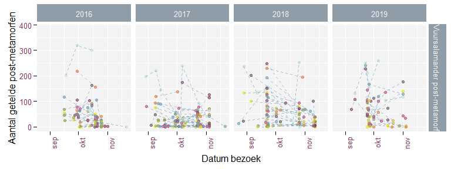

Figuur 19: Evolutie getelde aantallen binnen telperiode: Vuursalamander - post-metamorf

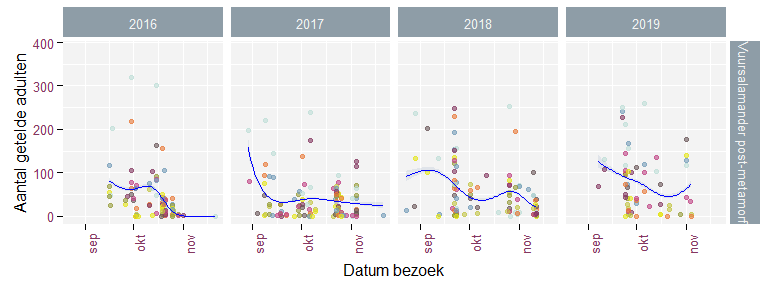

Figuur 20: Evolutie getelde aantallen binnen telperiode: Vuursalamander - post-metamorf

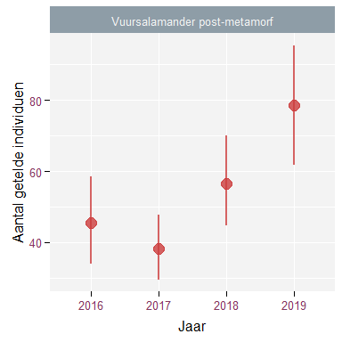

Figuur 21: Evolutie gemiddelde getelde aantallen per bezoek: Vuursalamander

# Libellen

## Overzicht monitoringsinspanning

| meetnet | monitoringsinspanning | 2016 | 2017 | 2018 | 2019 |
| --- | --- | --- | --- | --- | --- |
| Beekrombout | aantal tellingen |  |  |  | 9 |
|  | aantal tellers |  |  |  | 6 |
| Bosbeekjuffer | aantal tellingen |  |  | 27 | 15 |
|  | aantal tellers |  |  | 8 | 4 |
| Gevlekte witsnuitlibel | aantal tellingen | 51 | 51 | 52 | 53 |
|  | aantal tellers | 13 | 15 | 16 | 16 |
| Hoogveenglanslibel | aantal tellingen |  |  | 23 | 20 |
|  | aantal tellers |  |  | 10 | 6 |
| Kempense heidelibel | aantal tellingen | 15 | 14 | 16 | 5 |
|  | aantal tellers | 7 | 6 | 7 | 5 |
| Maanwaterjuffer | aantal tellingen | 19 | 18 | 15 | 15 |
|  | aantal tellers | 5 | 7 | 6 | 6 |
| Rivierrombout | aantal tellingen | 65 | 71 | 58 | 66 |
|  | aantal tellers | 11 | 14 | 11 | 10 |
| Speerwaterjuffer | aantal tellingen |  | 14 | 13 | 15 |
|  | aantal tellers |  | 7 | 6 | 9 |
| Variabele waterjuffer | aantal tellingen |  | 27 | 28 | 17 |
|  | aantal tellers |  | 13 | 9 | 8 |
| Vroege glazenmaker | aantal tellingen |  | 30 | 28 | 12 |
|  | aantal tellers |  | 12 | 12 | 5 |

## Overzicht getelde aantallen

### Primaire soorten

| meetnet | soort_wet | type waarneming | aantal | 2016 | 2017 | 2018 | 2019 |
| --- | --- | --- | --- | --- | --- | --- | --- |
| Beekrombout | Gomphus vulgatissimus | larvenhuidje mannelijk | gemiddeld |  |  |  | 0.0 |
|  |  |  | maximum |  |  |  | 0.0 |
|  |  |  | totaal |  |  |  | 0.0 |
|  |  | larvenhuidje onbekend | gemiddeld |  |  |  | 51.6 |
|  |  |  | maximum |  |  |  | 162.0 |
|  |  |  | totaal |  |  |  | 464.0 |
|  |  | larvenhuidje vrouwelijk | gemiddeld |  |  |  | 0.0 |
|  |  |  | maximum |  |  |  | 0.0 |
|  |  |  | totaal |  |  |  | 0.0 |
| Bosbeekjuffer | Calopteryx virgo | copula | gemiddeld |  |  | 0.2 | 0.1 |
|  |  |  | maximum |  |  | 4.0 | 1.0 |
|  |  |  | totaal |  |  | 6.0 | 2.0 |
|  |  | eiafzettend | gemiddeld |  |  | 0.0 | 0.0 |
|  |  |  | maximum |  |  | 0.0 | 0.0 |
|  |  |  | totaal |  |  | 0.0 | 0.0 |
|  |  | imago (niet uitgekleurd) | gemiddeld |  |  | 0.1 | 0.0 |
|  |  |  | maximum |  |  | 2.0 | 0.0 |
|  |  |  | totaal |  |  | 2.0 | 0.0 |
|  |  | imago mannelijk | gemiddeld |  |  | 26.4 | 11.9 |
|  |  |  | maximum |  |  | 118.0 | 37.0 |
|  |  |  | totaal |  |  | 713.0 | 178.0 |
|  |  | imago onbekend | gemiddeld |  |  | 0.0 | 0.0 |
|  |  |  | maximum |  |  | 0.0 | 0.0 |
|  |  |  | totaal |  |  | 0.0 | 0.0 |
|  |  | imago vrouwelijk | gemiddeld |  |  | 8.3 | 6.0 |
|  |  |  | maximum |  |  | 38.0 | 21.0 |
|  |  |  | totaal |  |  | 225.0 | 90.0 |
| Gevlekte witsnuitlibel | Leucorrhinia pectoralis | copula | gemiddeld | 0.0 | 0.0 | 0.2 | 0.0 |
|  |  |  | maximum | 2.0 | 0.0 | 3.0 | 0.0 |
|  |  |  | totaal | 2.0 | 0.0 | 8.0 | 0.0 |

[output cut: 132 more lines]

### Overige soorten

| soort_nl | soort_wet | type waarneming | 2016 | 2017 | 2018 | 2019 |
| --- | --- | --- | --- | --- | --- | --- |
| Azuurwaterjuffer | Coenagrion puella | copula | 25 | 104 | 170 | 156 |
|  |  | eiafzettend | 0 | 59 | 16 | 0 |
|  |  | eiafzettend | 0 | 11 | 3 | 0 |
|  |  | imago mannelijk | 256 | 358 | 523 | 452 |
|  |  | imago onbekend | 651 | 1533 | 458 | 266 |
|  |  | imago vrouwelijk | 0 | 21 | 52 | 20 |
| Bandheidelibel | Sympetrum pedemontanum | imago mannelijk | 2 | 0 | 0 | 4 |
|  |  | imago vrouwelijk | 0 | 0 | 0 | 4 |
| Beekoeverlibel | Orthetrum coerulescens | copula | 1 | 0 | 6 | 7 |
|  |  | eiafzettend | 1 | 0 | 2 | 2 |
|  |  | imago (niet uitgekleurd) | 1 | 15 | 120 | 8 |
|  |  | imago mannelijk | 30 | 31 | 177 | 60 |
|  |  | imago onbekend | 12 | 52 | 1 | 102 |
|  |  | imago vrouwelijk | 20 | 3 | 30 | 15 |
| Blauwe glazenmaker | Aeshna cyanea | imago mannelijk | 1 | 2 | 9 | 2 |
|  |  | imago onbekend | 0 | 1 | 0 | 0 |
|  |  | imago vrouwelijk | 0 | 0 | 0 | 1 |
| Bloedrode heidelibel | Sympetrum sanguineum | copula | 0 | 3 | 5 | 2 |
|  |  | imago (niet uitgekleurd) | 0 | 6 | 14 | 27 |
|  |  | imago mannelijk | 5 | 32 | 76 | 51 |
|  |  | imago onbekend | 165 | 22 | 294 | 194 |
|  |  | imago vrouwelijk | 0 | 7 | 5 | 4 |
| Bosbeekjuffer | Calopteryx virgo | imago mannelijk | 0 | 0 | 3 | 1 |
|  |  | imago vrouwelijk | 0 | 0 | 1 | 1 |
| Breedscheenjuffer | Platycnemis pennipes | copula | 5 | 0 | 2 | 0 |
|  |  | imago (niet uitgekleurd) | 0 | 0 | 1 | 0 |
|  |  | imago mannelijk | 57 | 11 | 16 | 21 |
|  |  | imago onbekend | 6 | 19 | 5 | 23 |
|  |  | imago vrouwelijk | 50 | 0 | 7 | 69 |
| Bruine glazenmaker | Aeshna grandis | imago mannelijk | 2 | 0 | 0 | 0 |

[output cut: 186 more lines]